# Government Health Expenditure

### Data Sources and Method overview

In this notebook we combine three data sources to produce a long-term time-series of government health expenditure as a share of GDP. The figure, taken from [‘the OECD’s public funding for health care brief (2020)’](https://www.oecd.org/health/Public-funding-of-health-care-Brief-2020.pdf), below shows public and private funding contribute to health care goods and services. The section we focus on in this notebook is highlighted in the grey boxes, expenditure which is either government schemes, social health insurance or compulsory health insurance.

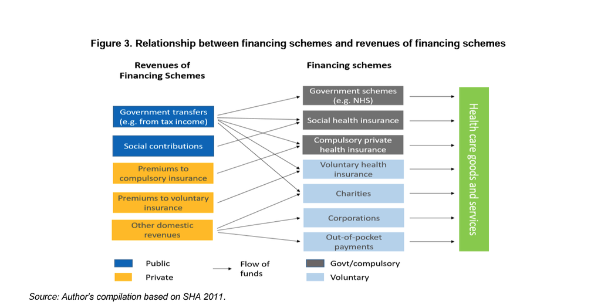

Figure from ‘Public funding for health care brief (OECD,2020)’

The data sources we use are [Lindert (1994)](https://drive.google.com/file/d/1YFlIC-on7oWiDhgdETUD9PSVE-BTaySn/view?usp=sharing), [OECD (1993)](https://drive.google.com/file/d/1Xa9WRtQq_Dfeod8mfJzcj6TGXak7APRF/view?usp=sharing.), [OECD Stat](https://stats.oecd.org/sdmx-json/data/DP_LIVE/.HEALTHEXP.../OECD?contentType=csv&detail=code&separator=comma&csv-lang=en) and were combined as follows:

For the period 1970-2020 we report the figures as published in OECD Stat. For the period 1960-1969, we extended the recent figures (from OECD Stat) backwards by using the rates of change as reported in OECD (1993). For the period 1880-1930, we report observations from Lindert (1994).

We use backward extrapolation because it is not possible to splice the estimates from OECD Stat and OECD (1993). This is because, while the trends are consistent, there are differences in levels due to changes in definitions and measurement.”

```r
library(dplyr)
library(ggplot2)
library(tidyr)
library(zoo)
```

### Download the data

```r
year <- format(Sys.Date(),"%Y")
oecd_stat_fp <- paste0("data/oecd_stat_",year,".csv")
download.file('https://stats.oecd.org/sdmx-json/data/DP_LIVE/.HEALTHEXP.../OECD?contentType=csv&detail=code&separator=comma&csv-lang=en', oecd_stat_fp )
```

### Standardise the countries

Loading in the country standardisation csv:

```r
countries <- read.csv("data/country_names_country_standardized.csv") %>% distinct()
```

### Loading and plotting the OECD Stat data

Reading in the data downloaded from OECD Stat. We are using the values relating to ‘Government/Compulsory’ expenditure - which is here coded ‘COMPULSORY’ in the ‘SUBJECT’ column.

In this code chunk we also standardise the country names to OWID country names.

We also add rows so that for each country every year between the first and last has its own row.

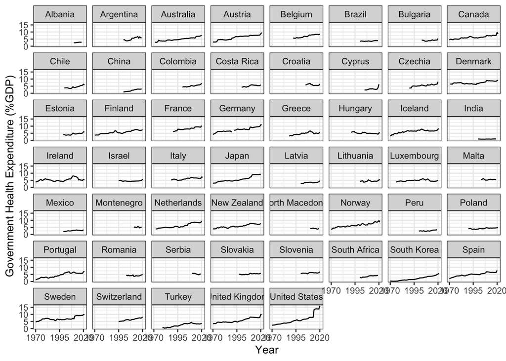

```r
oecd <- read.csv(oecd_stat_fp) %>% filter(SUBJECT == 'COMPULSORY' & MEASURE == 'PC_GDP') %>%
  select(entity = LOCATION, year = TIME,value = Value ) %>%
  mutate(source = 'oecd_stat')%>%
  left_join(., countries, by = c('entity'= 'Country')) %>%
  select(entity = Our.World.In.Data.Name, year, value, source)%>%
  group_by(entity) %>%
  tidyr::complete(year = full_seq(min(year):max(year), 1))

ggplot()+
  geom_line(data =oecd, aes(x = year, y = value, group = interaction(entity)))+
  labs(x = "Year", y= "Government Health Expenditure (%GDP)")+
  facet_wrap(.~entity)+
  scale_x_continuous(breaks=seq(1970, 2020, 25))+
  theme_bw()
```

### Loading and plotting the OECD 1993 data

Reading in the data from OECD 1993, which is available [here](https://drive.google.com/file/d/1Xa9WRtQq_Dfeod8mfJzcj6TGXak7APRF/view?usp=sharing.).

In this code chunk we also standardise the country names to OWID country names and filter out countries that aren’t in the OECD stat dataset.

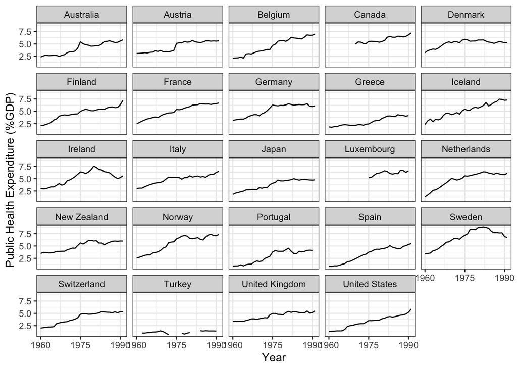

```r
oecd_93 <- read.csv("data/OECD 1993.csv") %>%
  pivot_longer(starts_with('X')) %>%
  mutate(entity = year, year = as.numeric(gsub("X","",name)), source = 'oecd_93') %>%
  left_join(., countries, by = c('entity'= 'Country')) %>%
  select(entity = Our.World.In.Data.Name, year, value, source)%>%
  filter(entity %in% oecd$entity)  %>%
  group_by(entity) %>%
  tidyr::complete(year = full_seq(min(year):max(year), 1))

ggplot()+
  geom_line(data =oecd_93, aes(x = year, y = value, group = interaction(entity)))+
  labs(x = "Year", y= "Public Health Expenditure (%GDP)")+
  facet_wrap(.~entity)+
  scale_x_continuous(breaks=seq(1960, 1990, 15))+
  theme_bw()
```

### Loading and plotting the Lindert data

Reading in the data from Lindert (1994) - The Rise of Social Spending 1880-1930 (Table 1D; Government subsidies for health care, 1880-1930, as percentage of national product at current prices.), available [here](https://drive.google.com/file/d/1YFlIC-on7oWiDhgdETUD9PSVE-BTaySn/view?usp=sharing).

In this code chunk we also standardise the country names to OWID country names.

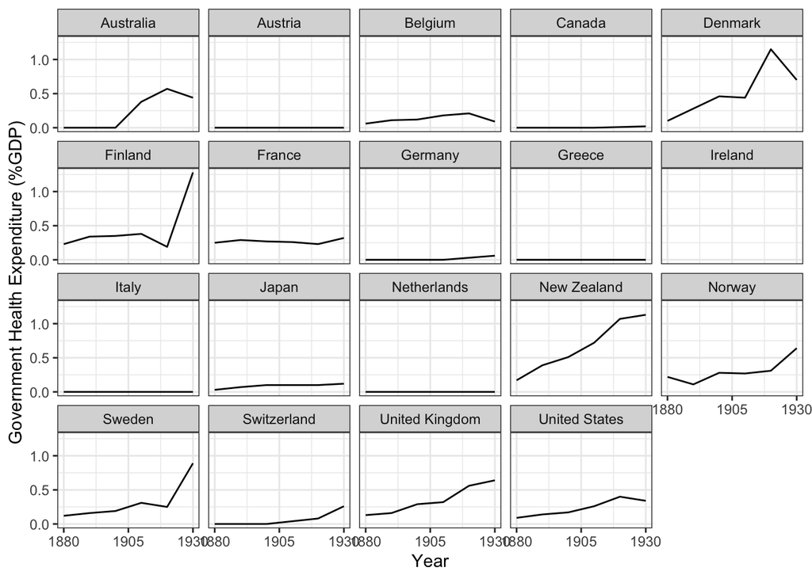

```r
lindert <- read.csv("data/lindert_1880_1930.csv") %>%
  left_join(., countries, by = c('entity'= 'Country')) %>%
  mutate(source = 'Lindert') %>%
  select(entity = Our.World.In.Data.Name, year, value = public_expenditure_on_health, source)%>%
  select(entity,year,value, source )

ggplot()+
  geom_line(data =lindert, aes(x = year, y = value, group = interaction(entity)))+
  labs(x = "Year", y= "Government Health Expenditure (%GDP)")+
  facet_wrap(.~entity)+
  scale_x_continuous(breaks=seq(1880, 1930, 25))+
  theme_bw()
```

### Linearly interpolating missing data Here we linearly interpolate missing data from both OECD datasets. For example the data for France between is only available every five years between 1970 and 1990, so we interpolate the missing values.

```r
oecd <- oecd %>% group_by(entity) %>%
  mutate(value = na.approx(value, na.rm = FALSE)) %>%
  ungroup()

oecd_93 <- oecd_93 %>% group_by(entity) %>%
  mutate(value = na.approx(value, na.rm = FALSE)) %>%
  ungroup()
```

### Combine the OECD datasets and plot the combined data

Here we combine both the datasets and plot them, coloured according to the source. Values which have been linearly interpolated (as described above) are shown as ‘OWID_estimate’.

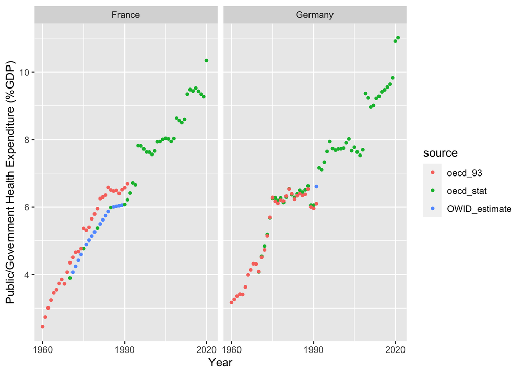

```r
oecd_both<- rbind(oecd, oecd_93)
oecd_both$source[is.na(oecd_both$source)] <- 'OWID_estimate'
ggplot()+
  geom_point(data =oecd_both %>% filter(entity %in%c('France', 'Germany')), aes(x = year, y = value, group = interaction(source,entity), colour = source), size = 1)+
  scale_x_continuous(breaks=seq(1960, 2020, 30))+
  labs(x = "Year", y= "Public/Government Health Expenditure (%GDP)")+
  facet_wrap(.~ entity)
```

### Calculating the rate of change in OECD Stat data

Calculating the rate of change in the OECD Stat data. Here we create a new column (time_m1) which is lagged by one year, for example values in the ‘value’ column for 1971 rows are shown as 1972 in the ‘time_m1’ column.

We then the divide the ‘time_m1’ column by the ‘value’ column to estimate the rate of change - in a backwards direction. So we would estimate the rate of change from 1972 to 1971.

```r
roc_df<- oecd %>%
  select(entity, year, value) %>%
  group_by(entity) %>%
  arrange(entity,year) %>%
  mutate(time_m1 = lag(value, n = 1L), br_roc = time_m1/value, source = 'oecd_stat') %>%
  ungroup() %>%
  filter(complete.cases(.))

head(roc_df)
```

```
# A tibble: 6 × 6
  entity   year value time_m1 br_roc source
  <chr>   <dbl> <dbl>   <dbl>  <dbl> <chr>
1 Albania  2011  2.39    2.44  1.02  oecd_stat
2 Albania  2012  2.47    2.39  0.965 oecd_stat
3 Albania  2013  2.60    2.47  0.950 oecd_stat
4 Albania  2014  2.62    2.60  0.995 oecd_stat
5 Albania  2015  2.76    2.62  0.950 oecd_stat
6 Albania  2016  2.84    2.76  0.969 oecd_stat
```

### Calculating the rate of change in OECD 1993 data

Calculating the rate of change in the OECD 1993 data. Here we create a new column (time_m1) which is lagged by one year, for example values in the ‘value’ column for 1971 rows are shown as 1972 in the ‘time_m1’ column.

We then the divide the ‘time_m1’ column by the ‘value’ column to estimate the rate of change - in a backwards direction. So we would estimate the rate of change from 1972 to 1971.

```r
oecd_93_roc <- oecd_93 %>%
  select(entity, year, value) %>%
  group_by(entity) %>%
  mutate(time_m1 = lag(value, n = 1L), br_roc = time_m1/value, source = 'oecd_93') %>%
  ungroup() %>%
  filter(complete.cases(.))
```

### Combine the rates of change

We combine the two rates of change - we can check the rate of change has been calculated as expected by looking at the values in the table below.

The 1962 value for Australia is 2.74, we multiply this by the 1962 value of the rate of change (br_roc), which is 0.9379562 to get the 1961 value of 2.57.

```r
roc_both <- rbind(oecd_93_roc, roc_df)
head(roc_both)
```

```
# A tibble: 6 × 6
  entity     year value time_m1 br_roc source
  <chr>     <dbl> <dbl>   <dbl>  <dbl> <chr>
1 Australia  1961  2.57    2.35  0.914 oecd_93
2 Australia  1962  2.74    2.57  0.938 oecd_93
3 Australia  1963  2.63    2.74  1.04  oecd_93
4 Australia  1964  2.64    2.63  0.996 oecd_93
5 Australia  1965  2.73    2.64  0.967 oecd_93
6 Australia  1966  2.68    2.73  1.02  oecd_93
```

### De-duplicating the rates of change

As there is some overlap in the time-series there are duplicate for some entity-rate_of_change pairs. In these cases we have a preference for OECD Stat.

```r
roc_both <- roc_both %>%
  left_join(., countries, by = c('entity'= 'Country')) %>%
  select(entity = Our.World.In.Data.Name, year, br_roc, source)

roc_both <- roc_both %>%
  group_by(entity, year) %>%
  add_count() %>%
  ungroup()

roc_sel <- roc_both[-which(roc_both$n >1 & roc_both$source == 'oecd_93'),]

head(roc_sel)
```

```
# A tibble: 6 × 5
  entity     year br_roc source      n
  <chr>     <dbl>  <dbl> <chr>   <int>
1 Australia  1961  0.914 oecd_93     1
2 Australia  1962  0.938 oecd_93     1
3 Australia  1963  1.04  oecd_93     1
4 Australia  1964  0.996 oecd_93     1
5 Australia  1965  0.967 oecd_93     1
6 Australia  1966  1.02  oecd_93     1
```

### Interpolating missing rates of change

There are some countries which have a gap between the OECD datasets (Belgium, Switzerland). For these we linearly interpolate the missing rate of change values.

```r
roc_int <- roc_sel %>%
  group_by(entity) %>%
  tidyr::complete(year = full_seq(min(year):max(year), 1))%>%
  mutate(br_roc = na.approx(br_roc, na.rm = FALSE)) %>%
  ungroup()

head(roc_int)
```

```
# A tibble: 6 × 5
  entity     year br_roc source      n
  <chr>     <dbl>  <dbl> <chr>   <int>
1 Australia  1961  0.914 oecd_93     1
2 Australia  1962  0.938 oecd_93     1
3 Australia  1963  1.04  oecd_93     1
4 Australia  1964  0.996 oecd_93     1
5 Australia  1965  0.967 oecd_93     1
6 Australia  1966  1.02  oecd_93     1
```

These interpolated values are labelled as ‘OWID_estimate’

```r
roc_int$source[is.na(roc_int$source)] <- 'OWID_estimate'
```

### Applying the rates of change to the OECD datasets

This loop iterates through each entity and within this iterates through each year (going backwards through time), to multiply the current ‘value’ by the current ‘br_roc’ (rate of change) to calculate the ‘value’ for the next year.

The calculations for each entity are combined as the loop runs.

```r
oecd_out <- oecd %>%
  select(entity, year, value)
oecd_loop <- NULL
entities <- unique(oecd_out$entity)
for (entity_sel in entities) {
  oecd_sel <- oecd_out %>%
    filter(entity == entity_sel)
  start_reg_year <- min(oecd_sel$year)
  min_roc_year <-
    roc_int %>% group_by(entity) %>%  filter(entity == entity_sel, year == min(year)) %>% ungroup() %>% select(year)  %>% pull()

  if (length(min_roc_year)  == 1) {
    if (min_roc_year <= start_reg_year) {
      years <- start_reg_year:min_roc_year
      for (year_sel in years) {
        roc_yr <-
          roc_int %>% filter(year == year_sel & entity == entity_sel)

        oecd_new <- oecd_sel %>% filter(year == year_sel) %>%
          mutate(value = value * roc_yr$br_roc, year = year_sel - 1) %>%
          select(entity, year, value)

        oecd_sel <- rbind(oecd_sel, oecd_new)

      }
    }
  }
  oecd_loop <- rbind(oecd_loop, oecd_sel)
}
```

### Adding Lindert data

Lastly, we add in the Lindert data.

```r
full_owid <- rbind(oecd_loop, lindert %>% select(-source))
full_owid <- full_owid %>% select(entity, year, public_health_expenditure_pc_gdp = value) %>% filter(complete.cases(.))

full_owid$source <- 'OWID_estimate'
```

### Plot and save the output

Plot countries which use all three datasets to check it looks sensible:

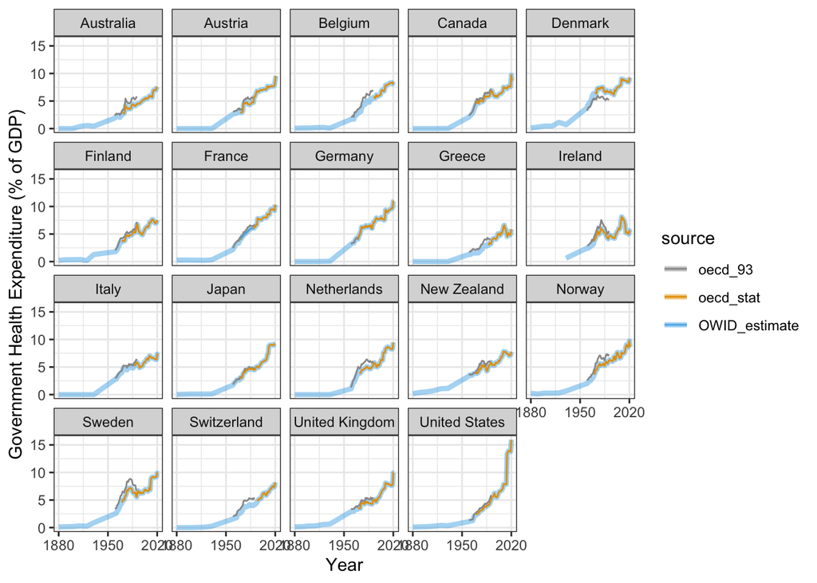

```r
ggplot()+
  geom_line(data = full_owid %>% filter(entity %in% lindert$entity), aes(x = year, y = public_health_expenditure_pc_gdp, group = entity, colour = source), size = 1.5, alpha =0.5)+
  geom_line(data =oecd_both%>% filter(entity %in% lindert$entity), aes(x = year, y = value, group = interaction(source,entity), colour = source))+
  facet_wrap(.~entity)+
  scale_x_continuous(breaks=seq(1880, 2020, 70))+
  scale_colour_manual(values=c("#999999", "#E69F00", "#56B4E9"))+
  theme_bw()+
  labs(x = "Year", y = "Government Health Expenditure (% of GDP)")
```

Write out the data.

```r
full_owid <- full_owid %>% select(-source)
write.csv(full_owid,paste0('data/OMM_government_health_expenditure_',year,'.csv'), row.names = FALSE)
```